# Unsuperwised_Learning

2023-02-01

```r
library(tidyverse) # für Tabellenbearbeitung und ggplot2
library(ggpubr) # hilfreiche Erweiterung der Plots
library(factoextra) #plot PCA
library(GGally) #Gruppenplots
library(ggpubr) #eine Bibliothek für publikationsreife Graphen
```

# Lernen ohne Vorwissen (Unsupervised Machine learning)

Eine häufige Fragestellung, die man bei der Datenanalyse zu beantworten sucht, ist die Frage nach Ähnlichkeiten von Datensätzen, deren “wahre” Klassenzuweisung man nicht kennt. So lassen sich unvoreingenommen Zusammenhänge erkennen und Gruppierungen finden, die sonst dem menschlichen Urteilsvermögen überlassen wären. Diese Fragestellung lässt sich mit Clustering-Methoden angehen. Wir lernen jedoch zunächst die PCA kennen, die strenggenommen keine Clusteringmethode ist, dafür aber wertvolle Interpretationsansätze liefert und vom Menschen leicht nachvollzogen werden kann.

## 1. Principal Component Analysis (PCA)

In erster Linie ist die PCA eine Methode, um den mehrdimensionalen Raum der Parameter zu reduzieren und die “wichtigsten” darin zu identifizieren. Die Messwerte der Parameter werden auf einen niederdimensionalen Raum projiziert, wobei die relative Lage der Datenpunkte erhalten bleibt. Dabei generiert die PCA neue Variablen aus vorhandenen, die die Varianz in den Daten maximieren. Eine PC ist eine Linearkombination der betrachteten Attribute PC1 = αVar1 + βVar2, so, dass die Varianz(PC1) maximal ist und die Loadings α^2 + β^2 = 1.

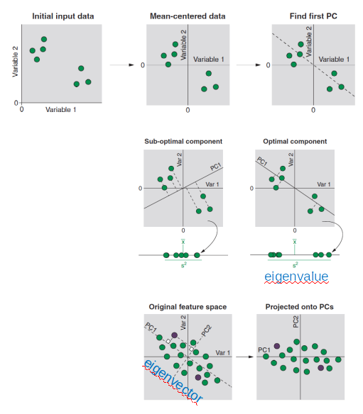

aus Rhys “Machine Learning with R, the Tidyverse, and Mlr”

Hat man die erste PC gefunden, wird die nächste PC senkrecht zu der ersten aufgebaut (Theoretisch ist die Anzahl der Komponenten = min(NAttribute ; NData- 1)). Daraus folgt, dass die erste PC die meiste Datenvarianz erklärt, die weiteren immer weniger. Man reduziert die Anzahl der Variablen, indem man nur die PCs weiter betrachtet, die den Großteil der Varianz erklären. Nebenbemerkung: Die Varianz der Daten entlang einer PC nennt man Eigenwert (eigenvalue)

Wir betrachten als Beispiel den Iris Datensatz. Dabei ändern wir zu Demonstrationszwecken die Einheit einer Messvariablen von cm in mm

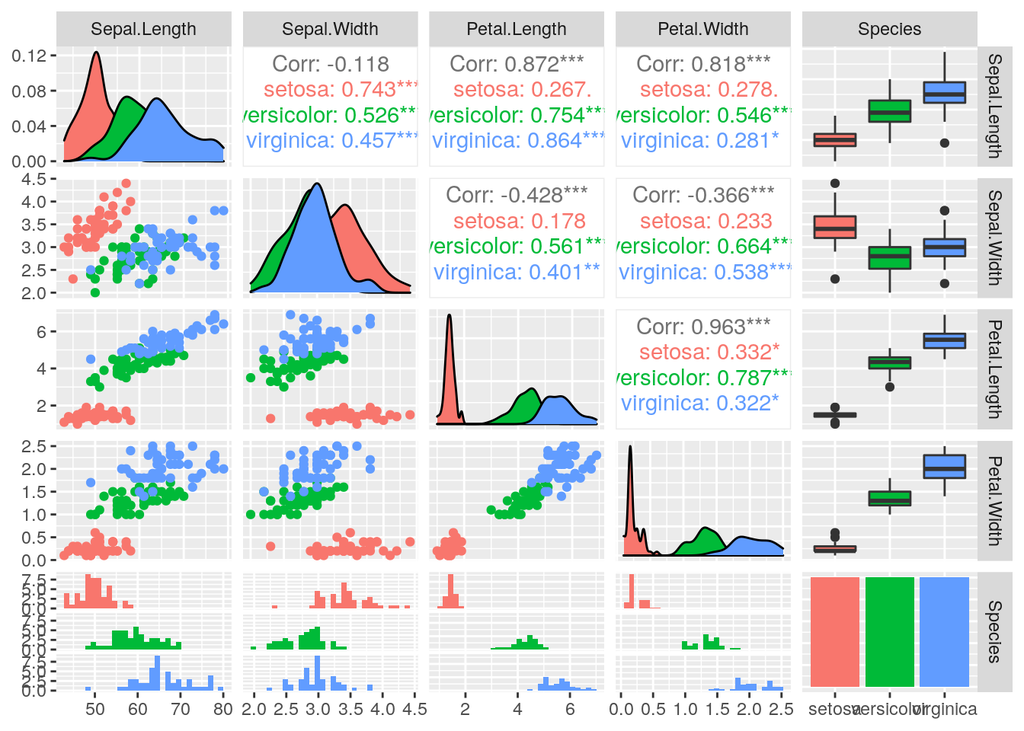

```r
iris$Sepal.Length <- iris$Sepal.Length * 10 #Ändern von cm in mm für Demozewck!
ggpairs(iris, mapping = aes(col=Species))
```

Das ist noch übersichtlich genug, aber viel mehr Variablen wird der Analyst nicht gut verarbeiten/darstellen können.

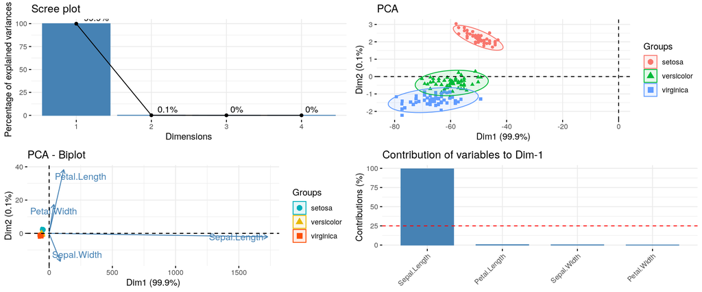

```r
#PCA
pca_unnorm <- prcomp(iris[ , !names(iris) %in% c("Species")] ,center = F,scale. = F)
#Samples plot
sam <- fviz_pca_ind(pca_unnorm, label="none", habillage=iris$Species,addEllipses=TRUE, ellipse.level=0.95, title=paste("PCA"))
#Loadings plot
loading <- fviz_pca_var(pca_unnorm, select.var = list(contrib = 15), col.var="contrib", repel=T, axes=c(1,2))+scale_color_gradient2(low="blue", mid="white",high="red")+theme_bw()
# Biplot Proben + Variablen
biplot <- fviz_pca_biplot(pca_unnorm, repel = TRUE, label = "var", # hide individual labels
             habillage = iris$Species,
             palette = c("#00AFBB", "#E7B800", "#FC4E07"),
             addEllipses = TRUE )
#Beitrag der Variablen zu PC1
beitrag <- fviz_contrib(pca_unnorm, choice = "var", axes = 1)
#Erklärte Varianz durch die einzelnen Komponenten
var_explained <- fviz_eig(pca_unnorm, addlabels=TRUE, hjust = -0.3)

figure <- ggarrange(var_explained, sam,biplot,beitrag,
                    ncol = 2, nrow=2)
figure
```

Hieran sieht man, dass die Variable mit der größten Varianz (Sepal.Length) den größten Beitrag zur PCA geliefert hat. Dies ist allerdings so nicht gewollt. Deswegen wiederholen wir dei PCA, wobei wir diesmal die Daten vorher skalieren.

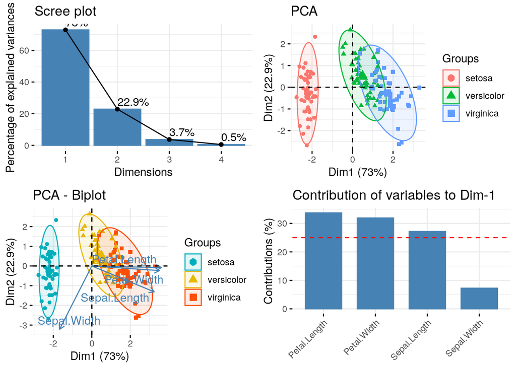

```r
#PCA
pca_norm <- prcomp(iris[ , !names(iris) %in% c("Species")] ,center = T,scale. = T)
#Samples plot
sam <- fviz_pca_ind(pca_norm, label="none", habillage=iris$Species,addEllipses=TRUE, ellipse.level=0.95, title=paste("PCA"))
#Loadings plot
loading <- fviz_pca_var(pca_norm, select.var = list(contrib = 15), col.var="contrib", repel=T, axes=c(1,2))+scale_color_gradient2(low="blue", mid="white",high="red")+theme_bw()
# Biplot Proben + Variablen
biplot <- fviz_pca_biplot(pca_norm, repel = TRUE, label = "var", # hide individual labels
             habillage = iris$Species,
             palette = c("#00AFBB", "#E7B800", "#FC4E07"),
             addEllipses = TRUE )

#Beitrag der Variablen zu PC1
beitrag <- fviz_contrib(pca_norm, choice = "var", axes = 1)
#Erklärte Varianz durch die einzelnen Komponenten
var_explained <- fviz_eig(pca_norm, addlabels=TRUE)
#fviz_screeplot(pca_norm, addlabels=TRUE, choice="variance")

figure <- ggarrange(var_explained, sam,biplot,beitrag,
                    ncol = 2, nrow=2)
figure
```

Das sieht schon besser aus. Die erste Komponente erklärt die Datenvarianz hauptsächlich durch die Variablen Petal.Length, Petal.Width, Sepal.Length. Aus dem Biplot erkennt man auch, dass Setosa in diesen Parametern kleinere Werte hat, jedoch leicht erhöhte Sepal.Width (Pfeilrichtung kombiniert mit Gruppenaufspaltung in PCA Plot). Im Screeplot sieht man, welchen Anteil der Varianz welche Hauptkomponente erklärt. Zur Dimensionsreduktion könnte man sich hier auf die beiden ersten Komponenten konzentrieren, da PC3 und erst recht PC4 verglichen mit PC1, PC2 einen weitaus geringeren Beitrag liefern und vernachlässigt werden können. Der PCA-Plot zeigt, dass es eine deutliche Aufspaltung von Iris setosa von den anderen beiden Irisarten gibt, während I. versicolor und I. virginica einander in den gewählten Parametern ähneln, womit wir den Bogen zur Clusteranalyse schlagen. Bemerkenswert daran ist, dass wir die Gruppen auftrennen können, OHNE vorher Attribute ausgewählt zu haben, die die Auftrennung vollziehen sollen, dies geschah “automatisch”. Anschließend können Sie sich auf die interessanten Features konzentrieren.  
Man kann sich die Daten für jeden einzelnen Datenpunkt und die Loadings auch in Tabellenform extrahieren:

```r
myscores <- pca_norm$x #scores der einzelnen Datenpunkte
head(myscores)
```

```
##            PC1        PC2         PC3          PC4
## [1,] -2.257141 -0.4784238  0.12727962  0.024087508
## [2,] -2.074013  0.6718827  0.23382552  0.102662845
## [3,] -2.356335  0.3407664 -0.04405390  0.028282305
## [4,] -2.291707  0.5953999 -0.09098530 -0.065735340
## [5,] -2.381863 -0.6446757 -0.01568565 -0.035802870
## [6,] -2.068701 -1.4842053 -0.02687825  0.006586116
```

```r
myloadings <- pca_norm$rotation #loadings der Attribute
head(myloadings)
```

```
##                     PC1         PC2        PC3        PC4
## Sepal.Length  0.5210659 -0.37741762  0.7195664  0.2612863
## Sepal.Width  -0.2693474 -0.92329566 -0.2443818 -0.1235096
## Petal.Length  0.5804131 -0.02449161 -0.1421264 -0.8014492
## Petal.Width   0.5648565 -0.06694199 -0.6342727  0.5235971
```

Innerhalb der PC2 haben die Sepalenlänge und -breite einen viel größeren Einfluss, weshalb man sich (für PC2) auf diese beiden Attribute fokussieren würde. Über die Funktion summary() kann man die wichtigen PCA-Parameter in Tabellenform betrachten:

```r
summary(pca_norm)
```

```
## Importance of components:
##                           PC1    PC2     PC3     PC4
## Standard deviation     1.7084 0.9560 0.38309 0.14393
## Proportion of Variance 0.7296 0.2285 0.03669 0.00518
## Cumulative Proportion  0.7296 0.9581 0.99482 1.00000
```

Die SD ist die Wurzel der Varianz entlang der jeweiligen Komponente (=eigenvalue). Teilt man jeden *eigenvalue* durch die Summe der *eigenvalues*, erhält man den jeweiligen Anteil der Komponente an der Varianz.

## 2. Clustering (k-Means, HCA)

Das Ziel des Clusterings ist es, Gruppen von Datensätzen zu finden, die zueinander ähnlicher sind, als zu Mitgliedern anderer Gruppen. Dabei braucht man **keine Klassenkenntnis**, um Muster zu erkennen (unsupervised learning). Es gibt diverse Clusteringmethoden, z.B.:

- „visuelles“ Clustering mit PCA, t-SNE
- Sphärisches Clustering (k-Means)
- Hierarchisches Clustering (HCA)
- Dichtebasiertes Clustering (DBSCAN, OPTICS)

### k-Means

Der k-Means Clusteringalgorithmus beinhaltet ff. Schritte:

- Setze k-Zentren zufällig in den Datenraum. Die Anzahl der Zentren (entspricht der Anzahl der erwarteten Cluster) muss man als Nutzer vorgeben!
- Miss Abstand von jedem Datenpunkt zu jedem Zentroid
- Weise die Klasse des dem Datenpunkt nächsten Zentroids zu
- Berechne Mittelpunkt (mean) des entstandenen Clusters => neuer Zentroid
- Wiederhole ab 2, bis sich die Zentroiden nicht verändern

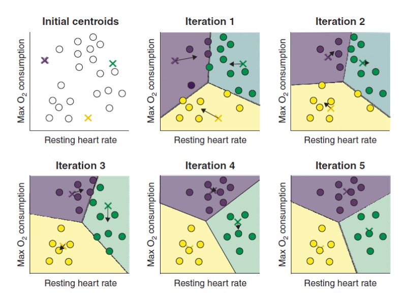

aus Rhys “Machine Learning with R, the Tidyverse, and Mlr”